# Bivariate Choropleth Plot using sf and ggplot package

Fahim Ahmed

2020-11-18

# Bivariate Choropleth Plot using “sf” and “ggplot” package

I am very closely follwing the instruction from this [tutorial](https://www.trafforddatalab.io/recipes/gis/bivariate_choropleth.html)

## A little about the dataset

The example dataset contains a list for the geophaphy of the United Kingdom (UK) at UTLA level and related attribute table. You can think the UTLA as a small geographic unit (i.e., region) in the UK. These geographic information are stored in the sf object. In the attribute table, the covid rate (tested +ve per 1000 people) and population (%) by ethnicity is collected from the ONS database at each UTLA level.

## Question/Objective:

The question related to the dataset is: *How the covid rate changes by ethnic population (%) at UTLA level?*

So, the objective is to map,

- covid rate (x variable)
- ethnic population (y variable)
- at UTLA (geophaphic variable)

One of the tools that can be used to answer the question is using a bivariate Choloropleth map.

## Assumption

We already created a dataset of type “list”. This dataset contains a “sf” object for geographic information and a dataframe provides a attributes related to geography.

1. Load Necessary Libaries and Datasets

```r
library(here)
library(janitor) # tallying categorical variable
library(cowplot)  # adding legend over the ggplot map
library(tidyverse) #
library(sf) # read/write/wrangle geographic data
library(classInt) # creating discrete intervals from continuous var
library(biscale)
library(pals) # color palette and color scale
```

```r
df <- st_read(here("data", "uk_utla_covid", "uk_utla_covid.shp"))
```

```r
classInt::classIntervals(df$covd_rt, n=3, style="quantile")
```

```
## style: quantile
##   one of 10,585 possible partitions of this variable into 3 classes
## [6.205475,16.08242) [16.08242,27.21737) [27.21737,60.46323]
##                  49                  49                  49
```

The three division quatiles values for covid rate are:

- $1:[6.205,16.08)$
- $2:[16.08,27.22)$
- $3:[27.22,60.46]$

The $1,2,3$ here represent the classes for covid rate. A vizualization for the quantile division is presented below:

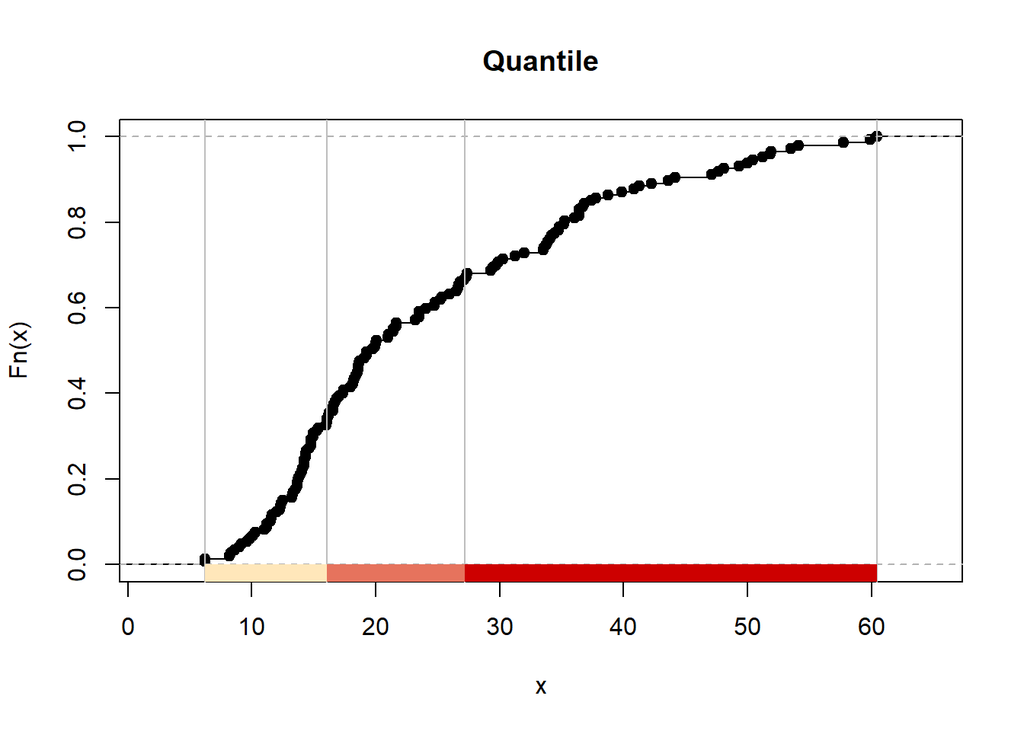

```r
pal1 <- c("wheat1", "red3")
plot(classInt::classIntervals(df$covd_rt, n=3, style="quantile"), pal=pal1, main="Quantile")
```

Similary, the 3 divisions for the black population is below:

```r
classInt::classIntervals(df$black, n=3, style="quantile")
```

```
## style: quantile
##   one of 10,585 possible partitions of this variable into 3 classes
## [0.09025204,0.6808119)   [0.6808119,2.801918)    [2.801918,27.16422]
##                     49                     49                     49
```

The three classes for the population of black ethnic group are:

- 1: [0.09025,0.6808)
- 2: [0.6808,2.802)
- 3: [2.802,27.16]

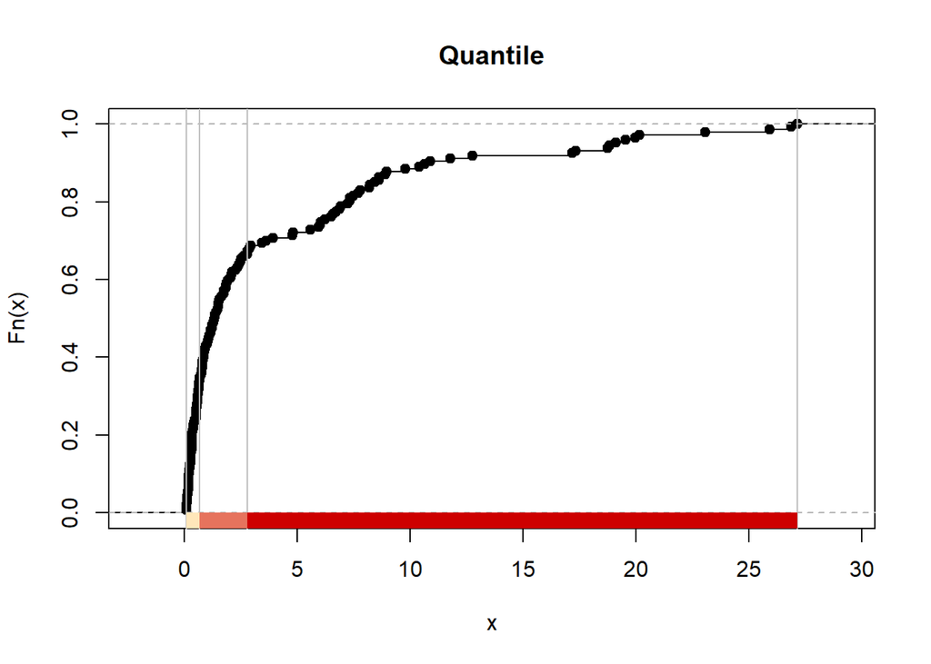

```r
plot(classInt::classIntervals(df$black, n=3, style="quantile"), pal=pal1, main="Quantile")
```

The following code creates the $bi\ class$ variable. It maps the x (=covid rate) division and y divisions (=black pop.) together.

```r
## A "df_clean" list is already created that contains a "sf" object and
## a "dataframe"


## Create a new column "bi_class" using x, y variable that
## 3 by 3; quantile division of the variables

data <-
  bi_class(
    df,     # <--- INPUT data set
    x = covd_rt,  # <-- variable 1 INPUT
    y = black,  # <-- variable 2 INPUT
    style = 'quantile',
    dim = 3
    )
```